# Introduction to Probabilistic Programming

## DataPhilly

## July 13, 2016

### [@Austin Rochford](https://twitter.com/AustinRochford) (arochford@monetate.com)

## Probabilistic Programming

- Programming with random variables
- User specifies a generative model for the observed data
  - "Tell the story" of how the data were created
- The language runtime/software library automatically performs inference

[figure not shown]

### What do we mean by inference?

- Maximum likelihood inference
- Maxumum a posteriori inference
- **Full posterior inference**

[figure not shown]

## Disease Testing

A certain rare disease affects one in 10,000 people. A test for the disease gives the correct result 99.9% of the time.

What is the probability that a given test is positive?

```python
import pymc3 as pm

with pm.Model() as pretest_disease_model:
    # This is our prior belief about whether or not the subject has the disease,
    # given its prevalence of the disease in the general population
    has_disease = pm.Bernoulli('has_disease', 1e-4)

    # This is the probability of a positive test given the presence or lack
    # of the disease
    p_positive = pm.Deterministic('p_positive',
                                  T.switch(T.eq(has_disease, 1),
                                           # If the subject has the disease,
                                           # this is the probability that the
                                           # test is positive
                                           0.999,
                                           # If the subject does not have the
                                           # disease, this is the probability
                                           # that the test is negative
                                           1 - 0.999))

    # This is the observed test result
    test_positive = pm.Bernoulli('test_positive', p_positive)
```

```python
samples = 40000
```

```python
with pretest_disease_model:
    step = pm.Metropolis()
    pretest_disease_trace = pm.sample(samples, step, random_seed=SEED)
```

```
 [-----------------100%-----------------] 40000 of 40000 complete in 6.1 sec
```

```python
pretest_disease_trace['test_positive']
```

```
array([0, 0, 0, ..., 0, 0, 0])
```

```python
pretest_disease_trace['test_positive'].size
```

```
40000
```

The probability that a given test is positive is

```python
pretest_disease_trace['test_positive'].mean()
```

```
0.001575
```

$$ \begin{align*} P(\textrm{Test } +) = &\ P(\textrm{Test } +\ |\ \textrm{Disease}) P(\textrm{Disease}) \\ & + P(\textrm{Test } +\ |\ \textrm{No disease}) P(\textrm{No disease}) \end{align*} $$

```python
0.999 * 1e-4  + (1 - 0.999) * (1 - 1e-4)
```

```
0.0010998000000000008
```

If a subject tests positive, what is the probability they have the disease?

```python
with pm.Model() as disease_model:
    # This is our prior belief about whether or not the subject has the disease,
    # given its prevalence of the disease in the general population
    has_disease = pm.Bernoulli('has_disease', 1e-4)

    # This is the probability of a positive test given the presence or lack
    # of the disease
    p_positive = pm.Deterministic('p_positive',
                                  T.switch(T.eq(has_disease, 1),
                                           # If the subject has the disease,
                                           # this is the probability that the
                                           # test is positive
                                           0.999,
                                           # If the subject does not have the
                                           # disease, this is the probability
                                           # that the test is negative
                                           1 - 0.999))

    # This is the observed positive test
    test_positive = pm.Bernoulli('test_positive', p_positive, observed=1)
```

```python
with disease_model:
    step = pm.Metropolis()
    disease_trace = pm.sample(samples, step, random_seed=SEED)
```

```
 [-----------------100%-----------------] 40000 of 40000 complete in 3.8 sec
```

The probability that someone who tests positive for the disease has it is

```python
disease_trace['has_disease'].mean()
```

```
0.096775
```

$$ \begin{align*} P(\textrm{Disease}\ |\ \textrm{Test }+) & = \frac{P(\textrm{Test }+\ |\ \textrm{Disease}) P(\textrm{Disease})}{P(\textrm{Test }+)} \end{align*} $$

```python
0.999 * 1e-4 / (0.999 * 1e-4 + (1 - 0.999) * (1 - 1e-4))
```

```
0.09083469721767587
```

## The Monty Hall Problem

[figure not shown]

If we select the first door and Monty opens the third to reveal a goat, should we change doors?

```python
with pm.Model() as monty_model:
    # We have no idea where the prize is at the beginning
    prize = pm.DiscreteUniform('prize', 0, 2)

    # The probability that Monty opens each door
    p_open = pm.Deterministic('p_open',
                              T.switch(T.eq(prize, 0),
                                       # If the prize is behind the first door,
                                       # he chooses to open one of the others
                                       # at random
                                       np.array([0., 0.5, 0.5]),
                                       T.switch(T.eq(prize, 1),
                                                # If it is behind the second door,
                                                # he must open the third door
                                                np.array([0., 0., 1.]),
                                                # If it is behind the third door,
                                                # he must open the second door
                                                np.array([0., 1., 0.]))))

    # Monty opened the third door, revealing a goat
    opened = pm.Categorical('opened', p_open, observed=2)
```

```python
samples = 10000
```

```python
with monty_model:
    step = pm.Metropolis()
    monty_trace = pm.sample(samples, step, random_seed=SEED)

monty_trace_df = pm.trace_to_dataframe(monty_trace)
```

```
 [-----------------100%-----------------] 10000 of 10000 complete in 1.4 sec
```

```python
monty_trace_df.head()
```

|  | p_open__0 | p_open__1 | p_open__2 | prize |
| --- | --- | --- | --- | --- |
| 0 | 0.0 | 0.0 | 1.0 | 1 |
| 1 | 0.0 | 0.5 | 0.5 | 0 |
| 2 | 0.0 | 0.0 | 1.0 | 1 |
| 3 | 0.0 | 0.0 | 1.0 | 1 |
| 4 | 0.0 | 0.0 | 1.0 | 1 |

```python
(monty_trace_df.groupby('prize')
               .size()
               .div(monty_trace_df.shape[0]))
```

```
prize
0    0.3196
1    0.6804
dtype: float64
```

## [PyMC3](http://pymc-devs.github.io/pymc3/)

> PyMC3 is a python module for Bayesian statistical modeling and model fitting which focuses on advanced Markov chain Monte Carlo fitting algorithms. Its flexibility and extensibility make it applicable to a large suite of problems.

Built on top of [`theano`](http://deeplearning.net/software/theano/)

- Dynamic generation of `C` code for models
- Automatic differentiation allows for gradient-based inference
  - Implements advanced Markov chain Monte carlo algorithms, such at the [No U-Turn Sampler](https://arxiv.org/abs/1111.4246)
  - Implements [automatic differentiation variational inference](http://arxiv.org/abs/1603.00788)
- Interoperable with both [`pandas`](http://pandas.pydata.org/) and [`patsy`](https://patsy.readthedocs.io/en/latest/)
- Provides clean support for multilevel models

[figure not shown]

## A/B Testing

[figure not shown]

```python
with pm.Model() as ab_model:
    # A priori, we have no idea what the purchase rate for variant A will be
    a_rate = pm.Uniform('a_rate')
    # We observed 40 purchases from 510 visitors who saw variant A
    a_purchases = pm.Binomial('a_purchases', 510, a_rate, observed=40)

    # A priori, we have no idea what the purchase rate for variant B will be
    b_rate = pm.Uniform('b_rate')
    # We observed 40 purchases from 510 visitors who saw variant A
    b_purchases = pm.Binomial('b_purchases', 505, b_rate, observed=45)
```

```
Applied interval-transform to a_rate and added transformed a_rate_interval to model.
Applied interval-transform to b_rate and added transformed b_rate_interval to model.
```

```python
samples = 10000
```

```python
with ab_model:
    step = pm.NUTS()
    ab_trace = pm.sample(samples, step, random_seed=SEED)
```

```
 [-----------------100%-----------------] 10000 of 10000 complete in 3.2 sec
```

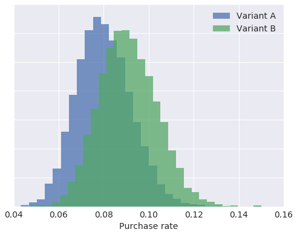

```python
fig
```

The probability that variant B is better than variant A is

```python
(ab_trace['a_rate'] < ab_trace['b_rate']).mean()
```

```
0.7218
```